# IODS course project

Tuukka Norri

# Introduction to Open Data Science - Course Project

# About the project

I believe I heard about this course from the mailing list of the doctoral school. I expect to brush up my knowledge on some of the statistical methods including PCA and factor analysis on this course. I have used R before. This file exists in [my Github repository](https://github.com/tsnorri/IODS-project).

```r
# This is a so-called "R chunk" where you can write R code.

date()
```

```
## [1] "Thu Nov 12 23:55:10 2020"
```

The text continues here.

# Chapter 2

I decided to start with the exercises and read the book if needed. I also decided to use Tidyverse (which includes ggplot2) and tidyr as I use them whenever possible when doing something with R. The e1071 library is needed for calculating kurtosis.

## Loading the data set

The data set used seems to contain results for a survey done for an introductory university course on social statistics. The variables are three averages calculated over answers to a subset of the questions each, an “attitude towards statistics” value determined from answers to some questions, as well as the gender, the age of the student and a total score calculated from the questions. According to comments in the original data set, the three derived variables indicate “surface approach” (surf), “strategic approach” (stra) and “deep approach” (deep.)

Below, the data is loaded and gender is transformed to an integer in order to make calculating a correlation matrix possible.

```r
library(tidyverse)
library(tidyr)
library(e1071)

df2 <- read_tsv("data/learning2014.tsv", col_types = cols(
  .default = col_double(),
  gender = col_character(),
  Age = col_integer(),
  Attitude = col_integer(),
  Points = col_integer()
))

df2 <- df2 %>% mutate(gender_ = recode(gender, M = -1, F = 1))
```

## Graphical overview of the data

Below are mean, median minimum and maximum values for each of the variables, as well as the counts of students by gender:

```r
df3 <- df2 %>% select(-c(gender, gender_))
df3 %>% summarise_all(tibble::lst(mean))
```

```
## # A tibble: 1 x 6
##   Age_mean Attitude_mean deep_mean stra_mean surf_mean Points_mean
##      <dbl>         <dbl>     <dbl>     <dbl>     <dbl>       <dbl>
## 1     25.5          31.4      3.68      3.12      2.79        22.7
```

```r
df3 %>% summarise_all(tibble::lst(median))
```

```
## # A tibble: 1 x 6
##   Age_median Attitude_median deep_median stra_median surf_median Points_median
##        <dbl>           <dbl>       <dbl>       <dbl>       <dbl>         <dbl>
## 1         22              32        3.67        3.19        2.83            23
```

```r
df3 %>% summarise_all(tibble::lst(min))
```

```
## # A tibble: 1 x 6
##   Age_min Attitude_min deep_min stra_min surf_min Points_min
##     <int>        <int>    <dbl>    <dbl>    <dbl>      <int>
## 1      17           14     1.58     1.25     1.58          7
```

```r
df3%>% summarise_all(tibble::lst(max))
```

```
## # A tibble: 1 x 6
##   Age_max Attitude_max deep_max stra_max surf_max Points_max
##     <int>        <int>    <dbl>    <dbl>    <dbl>      <int>
## 1      55           50     4.92        5     4.33         33
```

```r
df2 %>% select(gender) %>% group_by(gender) %>% tally
```

```
## # A tibble: 2 x 2
##   gender     n
##   <chr>  <int>
## 1 F        110
## 2 M         56
```

Below are histograms of the values.

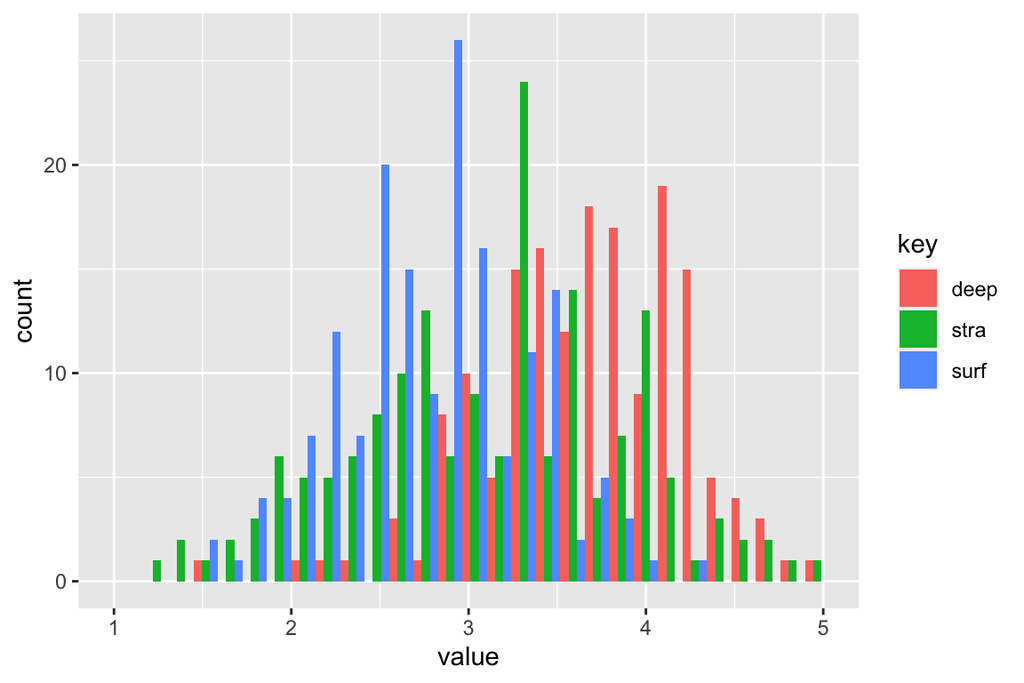

```r
scores_long <- df2 %>% select(c(deep, stra, surf)) %>% gather()
ggplot(scores_long, aes(x = value, fill = key)) +
  geom_histogram(position = "dodge") +
  xlim(1, 5)
```

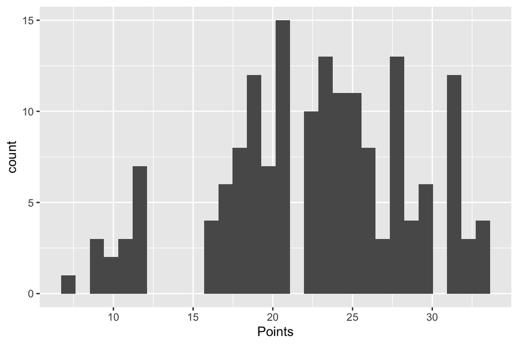

```r
ggplot(df2, aes(x = Points)) +
  geom_histogram()
```

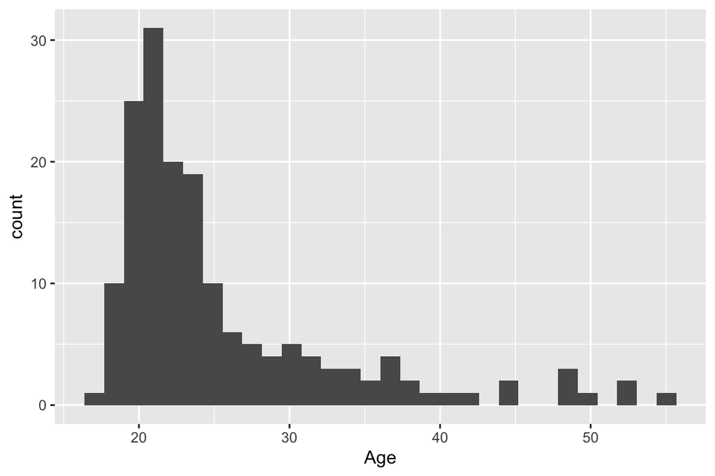

```r
ggplot(df2, aes(x = Age)) +
  geom_histogram()
```

The data look reasonably Gaussian, except for age, which clearly is not. Below the kurtoses of the variables are calculated to given an estimate on the gaussianity.

```r
df2 %>% select(-c(gender, gender_)) %>% summarise_all(tibble::lst(kurtosis)) %>% t
```

```
##                         [,1]
## Age_kurtosis       3.2396418
## Attitude_kurtosis -0.4788101
## deep_kurtosis      0.6615846
## stra_kurtosis     -0.4527415
## surf_kurtosis     -0.2714614
## Points_kurtosis   -0.2625437
```

The values for surf and points are close to zero and values for attitude, deep and stra are reasonably close, so the variables seem Gaussian.

Below is a correlation matrix calculated from the variables. The matrix is calculated using R’s built-in implementation for Spearman’s rank correlation coefficient, which I decided to use because some of the variables are discrete.

```r
cor(df2 %>% select(gender_, Age, Attitude, Points, surf, stra, deep), method = "spearman")
```

```
##              gender_         Age    Attitude      Points       surf        stra
## gender_   1.00000000 -0.19934006 -0.30088840 -0.09763168  0.1194377  0.14753714
## Age      -0.19934006  1.00000000 -0.00309789  0.06085512 -0.1530342  0.05065326
## Attitude -0.30088840 -0.00309789  1.00000000  0.44074335 -0.1673798  0.07755921
## Points   -0.09763168  0.06085512  0.44074335  1.00000000 -0.1409066  0.16950108
## surf      0.11943771 -0.15303419 -0.16737980 -0.14090656  1.0000000 -0.16145209
## stra      0.14753714  0.05065326  0.07755921  0.16950108 -0.1614521  1.00000000
## deep     -0.06842895  0.02059799  0.09167961 -0.01743412 -0.3209585  0.10575868
##                 deep
## gender_  -0.06842895
## Age       0.02059799
## Attitude  0.09167961
## Points   -0.01743412
## surf     -0.32095846
## stra      0.10575868
## deep      1.00000000
```

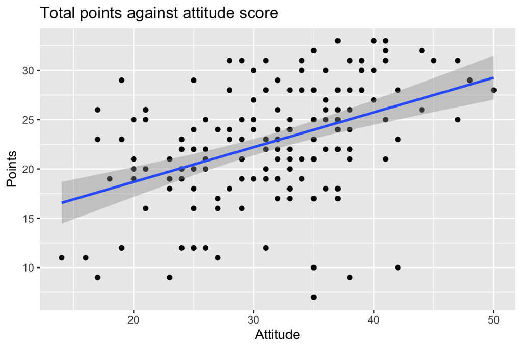

```r
ggplot(df2, aes(x = Attitude, y = Points)) +
  geom_point() +
  geom_smooth(method = "lm") +
  ggtitle("Total points against attitude score")
```

There is also a less-than-moderate negative correlation between gender and attitude, which indicates that males may have a more positive attitude to statistics.

```r
df2 %>% group_by(gender) %>% summarise(`Median attitude` = median(Attitude))
```

```
## # A tibble: 2 x 2
##   gender `Median attitude`
##   <chr>              <dbl>
## 1 F                   29.5
## 2 M                   34
```

Additionally, there is a less-than-moderate negative correlation between surf and deep.

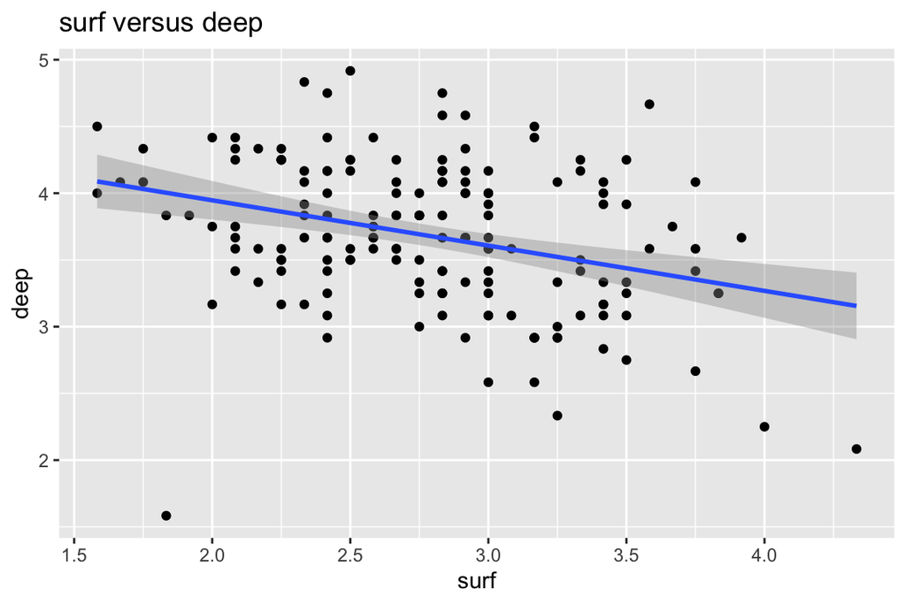

```r
ggplot(df2, aes(x = surf, y = deep)) +
  geom_point() +
  geom_smooth(method = "lm") +
  ggtitle("surf versus deep")
```

At this point, I decided to check the Datacamp exercises. Here is a plot with the student’s attitude versus exam points coloured by gender as done in the DataCamp exercise:

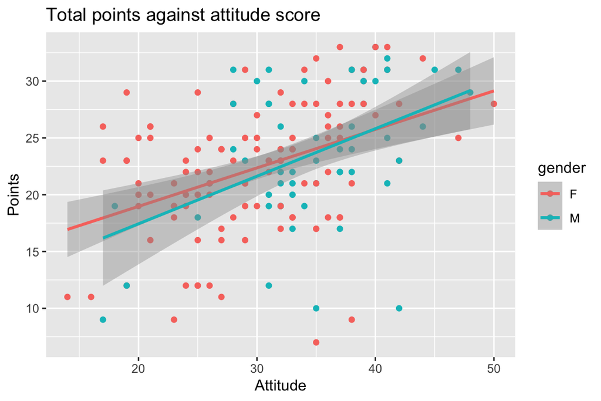

```r
ggplot(df2, aes(x = Attitude, y = Points, colour = gender)) +
  geom_point() +
  geom_smooth(method = "lm") +
  ggtitle("Total points against attitude score")
```

## Regression model

I could not find a simple way to do this with ggplot, so here is a solution similar to the Datacamp exercirses. I chose attitude, surf and stra as the explanatory variables as they had the highest absolute values for correlation with points.

```r
model <- lm(Points ~ Attitude + surf + stra, data = df2)
summary(model)
```

```
##
## Call:
## lm(formula = Points ~ Attitude + surf + stra, data = df2)
##
## Residuals:
##      Min       1Q   Median       3Q      Max
## -17.1550  -3.4346   0.5156   3.6401  10.8952
##
## Coefficients:
##             Estimate Std. Error t value Pr(>|t|)
## (Intercept) 11.01711    3.68375   2.991  0.00322 **
## Attitude     0.33952    0.05741   5.913 1.93e-08 ***
## surf        -0.58607    0.80138  -0.731  0.46563
## stra         0.85313    0.54159   1.575  0.11716
## ---
## Signif. codes:  0 '***' 0.001 '**' 0.01 '*' 0.05 '.' 0.1 ' ' 1
##
## Residual standard error: 5.296 on 162 degrees of freedom
## Multiple R-squared:  0.2074, Adjusted R-squared:  0.1927
## F-statistic: 14.13 on 3 and 162 DF,  p-value: 3.156e-08
```

The results indicate (in the Estimate column) that of the three variables, stra has the biggest effect on points. On the other hand, attitude is most likely to have an effect on the points, which may be seen from the probability in the last column. As the probability of getting a t value as high or higher when the null hypothesis of the coefficient being zero is true is low enought only for the attitude, it seems that only attitude from the three variables in question may be used to predict the number of points. In effect, when attitude increases by one unit, the prediction is that points increase by 0.34 units.

## Graphical model validation

In general, a linear regression model assumes that the target variable is a linear combination of the model parameters. Further, it is assumed that the errors are normally distributed and have constant variance.

The generated model assumes that total points are best explained by attitude, surf and stra. In other words, deep would not effect the total score. (The summary of the model indicates, though, that attitude is significant while surf and stra are not.)

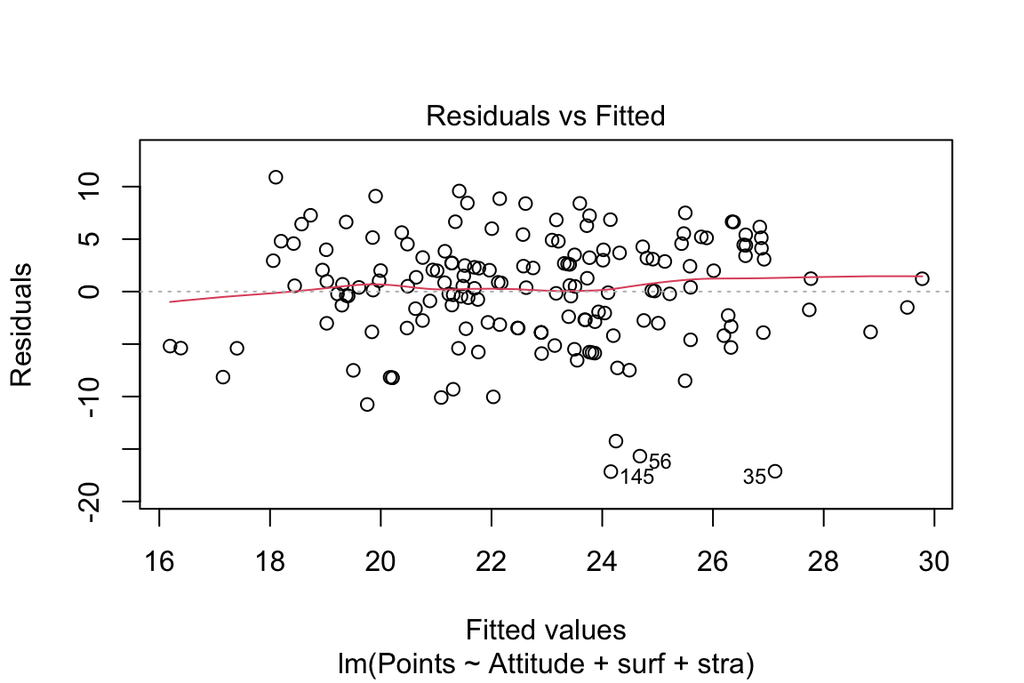

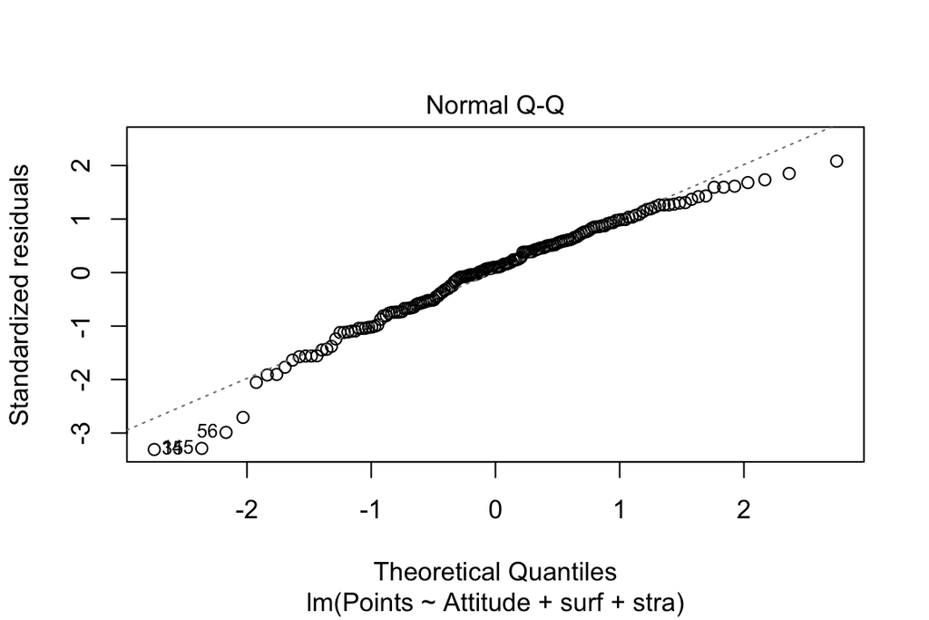

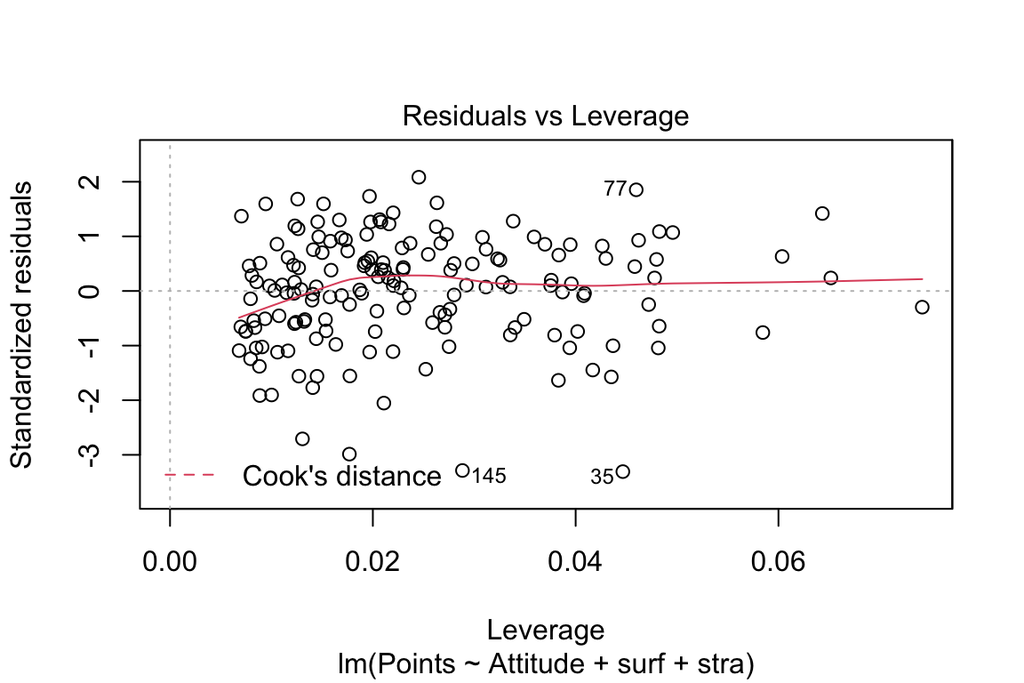

```r
plot(model, c(1, 2, 5))
```

As the residuals shown in the Q-Q plot mostly follow the line, the errors seem to be Gaussian. The residuals vs. fitted plot shows no discernible pattern, which would indicate the errors having constant variance. The residuals vs leverage plot indicates that no single observation has exceptionally high impact on the model, as the leverage value of each observation is relatively small.

# Chapter 3

## Reading the data

I am using the whole Tidyverse again, not just ggplot2 or dplyr, as well as tidyr.

```r
library(tidyverse)
library(tidyr)
library(questionr)
library(boot)

df0 <- read_tsv("data/student_alcohol_use.tsv", col_types = cols(
  .default = col_character(),
  age = col_integer(),
  Medu = col_integer(),
  Fedu = col_integer(),
  traveltime = col_integer(),
  studytime = col_integer(),
  failures = col_integer(),
  famrel = col_integer(),
  freetime = col_integer(),
  goout = col_integer(),
  Dalc = col_integer(),
  Walc = col_integer(),
  health = col_integer(),
  absences = col_integer(),
  G1 = col_integer(),
  G2 = col_integer(),
  G3 = col_integer(),
  alc_use = col_double(),
  high_use = col_logical()
))
```

## Guessing the relationship between alcohol consumption and other variables

I did the Datacamp exercises but forgot what the result was. My guess or recollection of some things that are associated with high alcohol consumption is:

- Males consume more alcohol than females
- Small amount of free time after school;
- No extra-curricular activities
- One of the parents staying at home

Below is a summary of the data.

```r
summary(df0)
```

```
##     school              sex                 age          address
##  Length:382         Length:382         Min.   :15.00   Length:382
##  Class :character   Class :character   1st Qu.:16.00   Class :character
##  Mode  :character   Mode  :character   Median :17.00   Mode  :character
##                                        Mean   :16.59
##                                        3rd Qu.:17.00
##                                        Max.   :22.00
##    famsize            Pstatus               Medu            Fedu
##  Length:382         Length:382         Min.   :0.000   Min.   :0.000
##  Class :character   Class :character   1st Qu.:2.000   1st Qu.:2.000
##  Mode  :character   Mode  :character   Median :3.000   Median :3.000
##                                        Mean   :2.806   Mean   :2.565
##                                        3rd Qu.:4.000   3rd Qu.:4.000
##                                        Max.   :4.000   Max.   :4.000
##      Mjob               Fjob              reason            nursery
##  Length:382         Length:382         Length:382         Length:382
##  Class :character   Class :character   Class :character   Class :character
##  Mode  :character   Mode  :character   Mode  :character   Mode  :character
##
##
##
##    internet           guardian           traveltime      studytime
##  Length:382         Length:382         Min.   :1.000   Min.   :1.000
##  Class :character   Class :character   1st Qu.:1.000   1st Qu.:1.000
##  Mode  :character   Mode  :character   Median :1.000   Median :2.000
##                                        Mean   :1.448   Mean   :2.037
##                                        3rd Qu.:2.000   3rd Qu.:2.000
##                                        Max.   :4.000   Max.   :4.000
##     failures       schoolsup            famsup              paid
##  Min.   :0.0000   Length:382         Length:382         Length:382
##  1st Qu.:0.0000   Class :character   Class :character   Class :character
##  Median :0.0000   Mode  :character   Mode  :character   Mode  :character
##  Mean   :0.2016
##  3rd Qu.:0.0000
##  Max.   :3.0000
##   activities           higher            romantic             famrel
##  Length:382         Length:382         Length:382         Min.   :1.000
##  Class :character   Class :character   Class :character   1st Qu.:4.000
##  Mode  :character   Mode  :character   Mode  :character   Median :4.000
##                                                           Mean   :3.937
```

[output cut: 8 more lines]

```
##  Max.   :5.00   Max.   :5.000   Max.   :5.000   Max.   :5.000   Max.   :5.000
##     absences          G1              G2              G3           alc_use
##  Min.   : 0.0   Min.   : 2.00   Min.   : 4.00   Min.   : 0.00   Min.   :1.007
##  1st Qu.: 1.0   1st Qu.:10.00   1st Qu.:10.00   1st Qu.:10.00   1st Qu.:1.007
##  Median : 3.0   Median :12.00   Median :12.00   Median :12.00   Median :1.270
##  Mean   : 4.5   Mean   :11.49   Mean   :11.47   Mean   :11.46   Mean   :1.482
##  3rd Qu.: 6.0   3rd Qu.:14.00   3rd Qu.:14.00   3rd Qu.:14.00   3rd Qu.:1.584
##  Max.   :45.0   Max.   :18.00   Max.   :18.00   Max.   :18.00   Max.   :3.296
##   high_use
##  Mode :logical
##  FALSE:307
##  TRUE :75
##
##
##
```

Below are histograms of the variables.

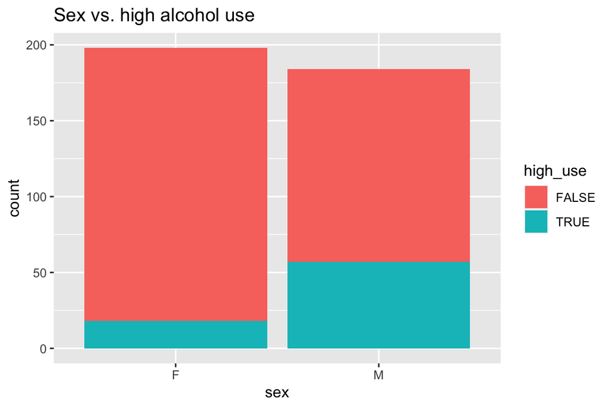

```r
ggplot(df0, aes(x = sex, fill = high_use)) + geom_bar() + ggtitle("Sex vs. high alcohol use")
```

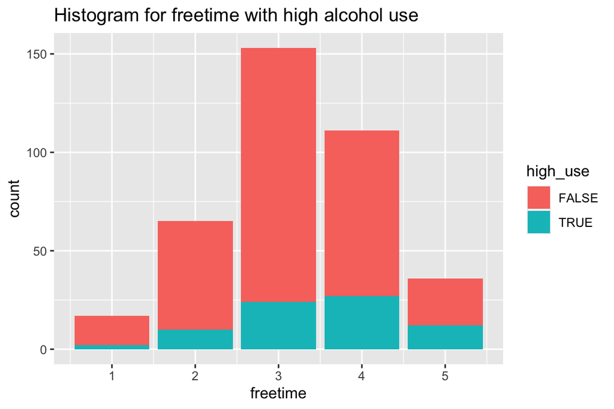

```r
ggplot(df0, aes(x = freetime, fill = high_use)) + geom_bar() + ggtitle("Histogram for freetime with high alcohol use")
```

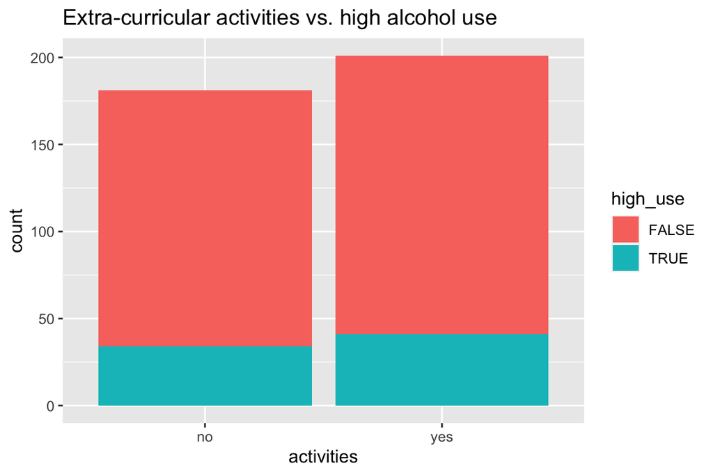

```r
ggplot(df0, aes(x = activities, fill = high_use)) + geom_bar() + ggtitle("Extra-curricular activities vs. high alcohol use")
```

Please see below for a plot for the parents’ jobs vs. high alcohol use.

## Exploring the relationships of the variables

I decided to transform the variables to numeric and calculate a correlation matrix. Here, binary variables are transformed to {-1, 1}. Other categorical measurements are transformed to (at least) ordinal if possible.

The variables Mjob, Fjob, reason and guardian are categorical and difficult to transform, so I plotted them instead.

```r
df1 <- df0 %>% mutate(
    high_use_ = Vectorize(function(val) { if (val) return (1) else { return (-1) }})(high_use)
  )

df2 <- df1 %>% mutate(
    school_ = recode(school, GP = -1, MS = 1),
    sex_ = recode(sex, M = -1, F = 1),
    address_ = recode(address, U = -1, R = 1),
    famsize_ = recode(famsize, LE3 = -1, GT3 = 1),
    Pstatus_ = recode(Pstatus, T = -1, A = 1),
    m_at_home = recode(Mjob, at_home = 1, .default = -1),
    f_at_home = recode(Fjob, at_home = 1, .default = -1),
    schoolsup_ = recode(schoolsup, yes = 1, no = -1),
    famsup_ = recode(famsup, yes = 1, no = -1),
    paid_ = recode(paid, yes = 1, no = -1),
    activities_ = recode(activities, yes = 1, no = -1),
    nursery_ = recode(nursery, yes = 1, no = -1),
    higher_ = recode(higher, yes = 1, no = -1),
    internet_ = recode(internet, yes = 1, no = -1),
    romantic_ = recode(romantic, yes = 1, no = -1)
  ) %>%
  select(-c(
    school,
    sex,
    address,
    famsize,
    Pstatus,
    Mjob,
    Fjob,
    reason,
    guardian,
    schoolsup,
    famsup,
    paid,
    activities,
    nursery,
    higher,
    internet,
    romantic
  ))
cor(
  x = df2 %>% select(-c(high_use, high_use_)),
  y = df2 %>% select(high_use_),
  method = "spearman"
)
```

```
##               high_use_
## age          0.05803437
## Medu         0.01693618
## Fedu         0.01417487
## traveltime   0.05407731
## studytime   -0.22656222
## failures     0.11573316
## famrel      -0.09439361
## freetime     0.13833505
## goout        0.35356847
## Dalc         0.54651084
## Walc         0.71476866
## health       0.11636775
## absences     0.17969439
## G1          -0.16759064
## G2          -0.14964691
## G3          -0.13927400
## alc_use      0.71476866
## school_     -0.03989242
## sex_        -0.27531819
## address_     0.04992972
## famsize_    -0.06782646
## Pstatus_     0.05591147
## m_at_home    0.01132896
## f_at_home   -0.10334296
## schoolsup_  -0.05838166
## famsup_     -0.09148788
## paid_        0.01650270
## activities_  0.02028154
## nursery_    -0.11566069
## higher_     -0.10779565
## internet_    0.02547942
## romantic_   -0.02488340
```

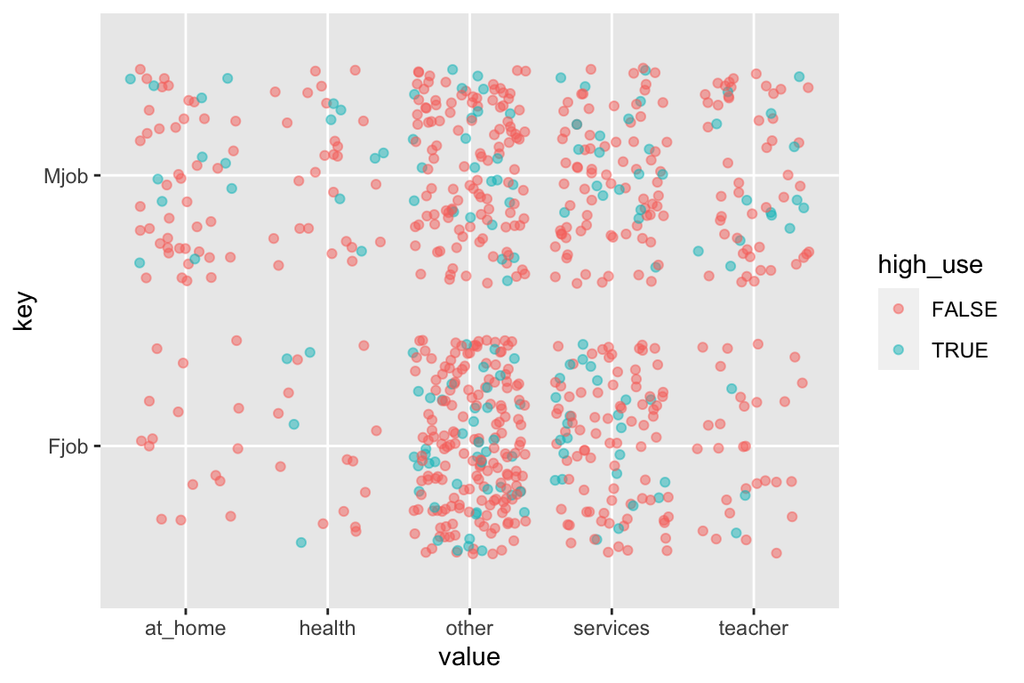

```r
df3 <- df1 %>% select(high_use, Mjob, Fjob) %>% gather(key, value, -c(high_use))
ggplot(df3, aes(x = value, y = key, colour = high_use)) + geom_jitter(alpha = 0.5)
```

The figure does not seem to be very telling. Here, frequencies for high alcohol use are counted for Mjob and Fjob.

```r
df1 %>% select(high_use, Mjob) %>% count(high_use, Mjob) %>% group_by(Mjob) %>% mutate(prop = prop.table(n))
```

```
## # A tibble: 10 x 4
## # Groups:   Mjob [5]
##    high_use Mjob         n  prop
##    <lgl>    <chr>    <int> <dbl>
##  1 FALSE    at_home     42 0.792
##  2 FALSE    health      26 0.788
##  3 FALSE    other      114 0.826
##  4 FALSE    services    77 0.802
##  5 FALSE    teacher     48 0.774
##  6 TRUE     at_home     11 0.208
##  7 TRUE     health       7 0.212
##  8 TRUE     other       24 0.174
##  9 TRUE     services    19 0.198
## 10 TRUE     teacher     14 0.226
```

```r
df1 %>% select(high_use, Fjob) %>% count(high_use, Fjob) %>% group_by(Fjob) %>% mutate(prop = prop.table(n))
```

```
## # A tibble: 9 x 4
## # Groups:   Fjob [5]
##   high_use Fjob         n   prop
##   <lgl>    <chr>    <int>  <dbl>
## 1 FALSE    at_home     16 1
## 2 FALSE    health      13 0.765
## 3 FALSE    other      168 0.796
## 4 FALSE    services    82 0.766
## 5 FALSE    teacher     28 0.903
## 6 TRUE     health       4 0.235
## 7 TRUE     other       43 0.204
## 8 TRUE     services    25 0.234
## 9 TRUE     teacher      3 0.0968
```

Below, frequencies are calculated for reason and guardian, too.

```r
df1 %>% select(high_use, reason) %>% count(high_use, reason) %>% group_by(reason) %>% mutate(prop = prop.table(n))
```

```
## # A tibble: 8 x 4
## # Groups:   reason [4]
##   high_use reason         n  prop
##   <lgl>    <chr>      <int> <dbl>
## 1 FALSE    course       111 0.793
## 2 FALSE    home          87 0.791
## 3 FALSE    other         24 0.706
## 4 FALSE    reputation    85 0.867
## 5 TRUE     course        29 0.207
## 6 TRUE     home          23 0.209
## 7 TRUE     other         10 0.294
## 8 TRUE     reputation    13 0.133
```

```r
df1 %>% select(high_use, guardian) %>% count(high_use, guardian) %>% group_by(guardian) %>% mutate(prop = prop.table(n))
```

```
## # A tibble: 6 x 4
## # Groups:   guardian [3]
##   high_use guardian     n  prop
##   <lgl>    <chr>    <int> <dbl>
## 1 FALSE    father      73 0.802
## 2 FALSE    mother     220 0.8
## 3 FALSE    other       14 0.875
## 4 TRUE     father      18 0.198
## 5 TRUE     mother      55 0.2
## 6 TRUE     other        2 0.125
```

Somehow there seems to be a possible connection between choosing the school for “other” reasons and high alcohol use. Below the correlation is calculated to make comparing easier.

```r
cor(
  x = df1 %>% select(high_use_),
  y = df1 %>% select(reason) %>% mutate(reason = recode(reason, other = 1, .default = -1)),
  method = "spearman"
)
```

```
##               reason
## high_use_ 0.07694401
```

The correlation is negligible.

To conclude, there are correlations between high alcohol use and the following:

- Positive with goout
- Positive with being male
- Negative with studytime

Even these are rather weak, though. Of the variables I guessed, only sex had a connection with high alcohol use according to the correlation coefficient.

## Logistic regression

The way I read the exercise I am supposed to keep using the same variables that I guessed.

Here is the model:

```r
df4 <- df0 %>% mutate(
    m_at_home = recode(Mjob, at_home = TRUE, .default = FALSE),
    f_at_home = recode(Fjob, at_home = TRUE, .default = FALSE),
    activities = Vectorize(function(val) { if ("yes" == val) return (TRUE) else { return (FALSE) }})(activities)
  ) %>%
  mutate(
    either_at_home = m_at_home | f_at_home
  )

m <- glm(high_use ~ sex + freetime + activities + either_at_home, data = df4, family = "binomial")
summary(m)
```

```
##
## Call:
## glm(formula = high_use ~ sex + freetime + activities + either_at_home,
##     family = "binomial", data = df4)
##
## Deviance Residuals:
##     Min       1Q   Median       3Q      Max
## -1.0803  -0.8047  -0.4566  -0.3717   2.2992
##
## Coefficients:
##                    Estimate Std. Error z value Pr(>|z|)
## (Intercept)        -3.03111    0.53269  -5.690 1.27e-08 ***
## sexM                1.44557    0.30430   4.751 2.03e-06 ***
## freetime            0.23085    0.14067   1.641    0.101
## activitiesTRUE     -0.06856    0.27198  -0.252    0.801
## either_at_homeTRUE  0.19863    0.38420   0.517    0.605
## ---
## Signif. codes:  0 '***' 0.001 '**' 0.01 '*' 0.05 '.' 0.1 ' ' 1
##
## (Dispersion parameter for binomial family taken to be 1)
##
##     Null deviance: 378.39  on 381  degrees of freedom
## Residual deviance: 345.40  on 377  degrees of freedom
## AIC: 355.4
##
## Number of Fisher Scoring iterations: 5
```

```r
odds.ratio(m, level = 0.95)
```

```
##                          OR    2.5 % 97.5 %         p
## (Intercept)        0.048262 0.016312 0.1323 1.269e-08 ***
## sexM               4.244258 2.379180 7.8877 2.029e-06 ***
## freetime           1.259676 0.959057 1.6672    0.1008
## activitiesTRUE     0.933734 0.547472 1.5948    0.8010
## either_at_homeTRUE 1.219728 0.553964 2.5322    0.6052
## ---
## Signif. codes:  0 '***' 0.001 '**' 0.01 '*' 0.05 '.' 0.1 ' ' 1
```

The model does not look convincing at all (only the student being male seems significant). Furthermore, the confidence intervals of the odds ratios of all the other variables contain the value one, which suggests that they are independent from high alcohol use. To fix this, I chose to use sex and study time as explaining variables.

```r
m1 <- glm(high_use ~ sex + studytime, data = df4, family = "binomial")
summary(m1)
```

```
##
## Call:
## glm(formula = high_use ~ sex + studytime, family = "binomial",
##     data = df4)
##
## Deviance Residuals:
##     Min       1Q   Median       3Q      Max
## -1.0033  -0.8096  -0.4519  -0.3515   2.3727
##
## Coefficients:
##             Estimate Std. Error z value Pr(>|z|)
## (Intercept)  -1.1851     0.4569  -2.594  0.00949 **
## sexM          1.2833     0.3047   4.211 2.54e-05 ***
## studytime    -0.5227     0.1900  -2.751  0.00594 **
## ---
## Signif. codes:  0 '***' 0.001 '**' 0.01 '*' 0.05 '.' 0.1 ' ' 1
##
## (Dispersion parameter for binomial family taken to be 1)
##
##     Null deviance: 378.39  on 381  degrees of freedom
## Residual deviance: 340.03  on 379  degrees of freedom
## AIC: 346.03
##
## Number of Fisher Scoring iterations: 5
```

```r
odds.ratio(m1, level = 0.95)
```

```
##                  OR   2.5 % 97.5 %         p
## (Intercept) 0.30572 0.12350 0.7440  0.009487 **
## sexM        3.60860 2.01699 6.6993 2.538e-05 ***
## studytime   0.59294 0.40259 0.8493  0.005936 **
## ---
## Signif. codes:  0 '***' 0.001 '**' 0.01 '*' 0.05 '.' 0.1 ' ' 1
```

The summary indicates that the student being male increases the log odds of high alcohol use by approximately 1.28. Each unit increase in study time decreases the log odds of high alcohol use by approximately 0.5. The p values (in the last column) indicate that the former is significant and the latter is somewhat significant. Additionally the confidence intervals of the odds ratios of both of the variables do not contain the value one and hence the variables may be connected to high alcohol use.

Below the predictive power of the model is tested.

```r
probabilities <- predict(m1, type = "response")
df4 <- df4 %>%
  mutate(probability = probabilities) %>%
  mutate(prediction = (0.5 < probability))

table(high_use = df4$high_use, prediction = df4$prediction)
```

```
##         prediction
## high_use FALSE
##    FALSE   307
##    TRUE     75
```

For some reason the model did not work at all; its performance was equivalent to guessing that no one of the students is classified as using much alcohol. The training error is 75 / 382 ≈ 0.196.

Below 10-fold cross-validation is tested.

```r
loss_func <- function(class, prob) {
  n_wrong <- abs(class - prob) > 0.5
  mean(n_wrong)
}

cv <- cv.glm(data = df4, cost = loss_func, glmfit = m1, K = 10)
cv$delta
```

```
## [1] 0.1963351 0.1963351
```

On one hand the prediction error is in fact lower than in Datacamp’s model. On the other hand, the usefulness of either such a model (or both) or the metric seems questionable because by guessing one can seemingly get a better result.